# This routine generates multiple social indicators at the municipal level for household surveys from 2011 to 2018.

Household surveys are created annually by the General Directorate of Statistics and Census. The survey allows generating indicators at the departmental level, however, there are 50 municipalities that are self-represented. In other words, the sample in these municipalities is large enough to be representative of themselves.

El Salvador has 262 municipalities, however in these 50 municipalities lives more than 65% of the population.

```python
import pandas as pd
import numpy as np
import os
import warnings
import plotly.express as px
from plotly.offline import init_notebook_mode
init_notebook_mode(connected=True)
import plotly.graph_objects as go
warnings.filterwarnings('ignore')
```

### GINI and the MEDIAN INCOME

I am interested in calculating the GINI and the median income in each municipality.

The survey calculates a frequency weighting for each respondent.

I have created a function that takes into account the frequency of each respondent. In addition, the GINI is calculated at the household income level and at the individual level.

```python
######## defining the GINI indicator########

def gini(EHPM, n_deciles=10, hogar=False):
    """Calculate the GINI of household surveys in El Salvador"""

    #main input
    x2 = EHPM[['ytot_ch','factor_ch','idp_ci','factor_ci','pc_ytot_ch']]

    #ytot_ch: Total household income
    #factor_ch: Weighted frequency of households
    #idp_ci: Type of survey (1=households; 0=individual)
    #factor_ci: Weighted frequency of individuals
    #pc_ytot_ch: Average income of each household member

    #defining the vars depending on the level required (Hogar: True = at the household level)
    if hogar==True:
        x2 = x2[x2['idp_ci']==1]
        x2['factor']= x2['factor_ch']
        x2['ytot'] = x2['ytot_ch']
    else:
        x2['factor'] = x2['factor_ci']
        x2['ytot'] = x2['pc_ytot_ch']

    #######sorting the data and creating the accumulated frequencies and then generating the deciles#####

    #sorting the data
    x2 = x2[x2['ytot'].notna()]
    x2 = x2.sort_values(by='ytot',ascending=True)
    x2['income'] = x2['ytot']*x2['factor']
    x2['x'] = x2['factor'].cumsum()/x2['factor'].sum()

    #creating a var for each decile
    deciles = np.linspace(0, 1, n_deciles + 1)
    x2['decil']=((pd.cut(x2['x'], deciles,labels=False))+1)

    #creating a table with the accumulated income in each decile and the expected income
    x3 = pd.pivot_table(x2,values='income',index=['decil'],aggfunc=np.sum).reset_index()
    x3['accumulated income'] = x3['income'].cumsum()/x3['income'].sum()
    x3['expected income'] = x3['decil']*(1/n_deciles)

    #calculating income difference between the accumulated per qunitil and the expected
    x3['dif']=x3['expected income']-x3['accumulated income']

    #calculating the difference relative to the total expected value (GINI)
    return x3.dif.sum()/x3['expected income'].sum()
```

```python
##### calculating the median of any indicator in the database, taking intoaccount the weighted frequency

def median(dataframe):
    """Extract the average of "values" given the weighted frequency "weights" (dataframe['values', 'weights'])"""

    #sorting the data
    dataframe.sort_values(by=dataframe.columns[0], ascending=True, inplace=True)

    #definind the vars
    values = dataframe.iloc[:,0]
    weights = dataframe.iloc[:,1]

    #deleting data containing na values
    weights = weights[values.notna()]
    values = values.dropna()
    order = weights.cumsum()

    #extrayendo el valor de la mediana
    median = values[order<=weights.sum()/2].max()

    return median
```

```python
#folder where I have the data
os.chdir(r'/Users/eleno/Documents/Documents/EHPM/Data')
```

### Creating a routine for every survey

The next code create multiples social indicators for each municipio

```python
#defining the years to use in each survey
year = ['2010','2011','2012','2013','2014','2015','2016','2017','2018']

#creating an empty dataframe to store the new data
data = pd.DataFrame()

for year in year:
    #reading the files in dta format
    x1 = pd.read_stata('SLV_'+year+'a_BID.dta', convert_categoricals=False, convert_missing=False)

    #### Preparing the data

    #using data at the individual level
    x1 = x1[x1['miembros_ci']==1]

    #calculating total income
    x1['ytot_ci'] = x1[['ylm_ci','ylnm_ci','ynlm_ci','ynlnm_ci']].sum(axis=1)

    #defining na values
    x1.loc[x1[['ylm_ci','ylnm_ci','ynlm_ci','ynlnm_ci']].isna().product(axis=1)==1,'ytot_ci']=np.nan

    #calculating income per capita at each home
    x1['ytot_ch'] = x1.groupby('idh_ch')['ytot_ci'].transform('sum')
    x1.loc[x1.ytot_ch<=0,'ytot_ch']=np.nan
    x1['pc_ytot_ch'] = x1['ytot_ch']/x1['nmiembros_ch']

    ###Extracting the municipality code from the survey

    #the variables created to define the municipalities is different depending on the survey
    #so I have built several cases to define the variable

    if (year=='2015')|(year=='2016')|(year=='2017')|(year=='2018'):
        municipios = x1[x1['autorrepresentado']==1]['codigomunic'].drop_duplicates().values

        if (municipios>100).sum()!=50:
            x1['codigomunic']=x1['r005']
            municipios = x1[x1['municauto']<50]['r005'].drop_duplicates().values

    if (year=='2011')|(year=='2012')|(year=='2013'):
        x1['product']=100
        x1['codigomunic']= x1['munic']+x1['product']*x1['region_c']
        municipios = x1[x1['munic_auto']<50]['codigomunic'].drop_duplicates().values

    if year=='2014':
        x1['codigomunic']=x1['municipio']
        municipios = x1[x1['munic_auto']<50]['municipio'].drop_duplicates().values

    if year == '2010':
        x1['product']=100
        x1['codigomunic']= x1['munic_auto']+x1['product']*x1['region_c']
        municipios = x1[x1['munic_auto']<50]['codigomunic'].drop_duplicates().values

    #calculating multiple indicators for each municipality

    for mun in municipios:

        x = x1[x1['codigomunic']==mun]

        #Average and median total income
        y = x[['ytot_ci','factor_ci']][x['ytot_ci'].notna()] #droping na values
        ytot_av = np.average(y['ytot_ci'],weights=y['factor_ci'])
        ytot_med = median(y[['ytot_ci','factor_ci']])

        #Average and median household income per capita
        y = x[['ytot_ci','factor_ci','pc_ytot_ch']][(x['ytot_ci'].notna()) & (x['pc_ytot_ch'].notna())] #droping na values
        pc_ytot_av = np.average(y['pc_ytot_ch'],weights=y['factor_ci'])
        pc_ytot_med = median(y[['pc_ytot_ch','factor_ci']])

        #Population
        Population = x['factor_ci'].sum()

        #Number of poor people in the municipality
        pob_extr = x[x['pobreza']==1]['factor_ci'].sum()
        pob_rela = x[x['pobreza']==2]['factor_ci'].sum()
        no_pobre = x[x['pobreza']==3]['factor_ci'].sum()

        #Percentage of household receiving remittances
        remesas_percentage = x[x['remesas_ch']>0]['factor_ch'].sum()/x['factor_ch'].sum()

        #Percentage of people working in differents sectors
        agriculture_wf = x[x['rama_ci']==1]['factor_ch'].sum()/x[x['rama_ci']>0]['factor_ch'].sum()
        industrial_wf = x[x['rama_ci']==3]['factor_ch'].sum()/x[x['rama_ci']>0]['factor_ch'].sum()
        services_wf = x[x['rama_ci']==6]['factor_ch'].sum()/x[x['rama_ci']>0]['factor_ch'].sum()

        #Percentage of economically active people
        pea = x[x['pea_ci']==1]['factor_ch'].sum()/x['factor_ch'].sum()

        #Number of unemployed people in the municipality
        desempleo = x[x['desemp_ci']==1]['factor_ci'].sum()
        empleo =  x[x['desemp_ci']==0]['factor_ci'].sum()

        #Number of people employed in the informal sector in the municipality
        informal = x[x['formal_ci']==0]['factor_ci'].sum()
        formal = x[x['formal_ci']==1]['factor_ci'].sum()

        #Years studied on average by population
        y = x[['aedu_ci','factor_ci']][x['aedu_ci'].notna()]

        escolar = np.average(y['aedu_ci'],weights=y['factor_ci'])

        #Gini
        gini_ci = gini(x,n_deciles=10,hogar=False) #calculating individual inequality
        gini_ch = gini(x,n_deciles=10,hogar=True) #calculating household inequality

        #storing the values created in the dataframe
        df = pd.DataFrame({'COD_MUN':mun,
                         'Year': float(year),
                         'Average Income': ytot_av,
                         'Median Income': ytot_med,
                         'Average Household Income per capita': pc_ytot_av,
                         'Median Household Income per capita': pc_ytot_med,
                         'Extreme poverty': pob_extr,
                         'Relative poverty': pob_rela,
                         'Not poor': no_pobre,
                         'Unemployment': desempleo,
                         'Working population':empleo,
                         'Informal jobs': informal,
                         'Formal jobs':formal,
                         'Years of schooling': escolar,
                         'Gini_ci': gini_ci,
                         'Gini_ch': gini_ch,
                         'Remittances %': remesas_percentage,
                         'Agriculture workforce %': agriculture_wf,
                         'Industrial workforce %': industrial_wf,
                         'Services workforce %': services_wf,
                         'Economically active population %': pea,
                         'Population':Population
                        },index=[0])

         #appending the data for each municipality
        data = data.append(df, ignore_index = True)

data = data.reset_index(drop=True)
```

```python
#Calculating percentage of poverty, informality and unemployment

#Percentage of poverty
data['Poverty ratio'] = data[['Extreme poverty','Relative poverty']].sum(axis=1)/\
                          data[['Extreme poverty','Relative poverty','Not poor']].sum(axis=1)

#Percentage of unemployment
data['Unemployment %'] = data['Unemployment']/\
                          data[['Unemployment','Working population']].sum(axis=1)

#Percentage of informality
data['Informal jobs ratio'] = data['Informal jobs']/\
                          data[['Informal jobs','Formal jobs']].sum(axis=1)
```

```python
#calculating job growth

#creating a table to facilitate iteration
x2 = pd.pivot_table(data, values='Working population',index=['COD_MUN'],columns=['Year'],aggfunc=np.sum).reset_index()

anios = np.arange(2011,2019)
anios2 = np.arange(2010,2018)

y2 = pd.DataFrame()

for x,y in zip(anios,anios2):
    y3 = pd.DataFrame()
    y3['Jobs growth'] = (x2[x]-x2[y])/x2[y]
    y3['Year']= x
    y3['COD_MUN'] = x2['COD_MUN']
    y2 = y2.append(y3)

#Merging the new variables
data = pd.merge(data,y2,on=['Year','COD_MUN'],how='inner')
```

### Printing output data

```python
data.head()
```

|  | COD_MUN | Year | Average Income | Median Income | Average Household Income per capita | Median Household Income per capita | Extreme poverty | Relative poverty | Not poor | Unemployment | ... | Remittances % | Agriculture workforce % | Industrial workforce % | Services workforce % | Economically active population % | Population | Poverty ratio | Unemployment % | Informal jobs ratio | Jobs growth |
| --- | --- | --- | --- | --- | --- | --- | --- | --- | --- | --- | --- | --- | --- | --- | --- | --- | --- | --- | --- | --- | --- |
| 0 | 311 | 2011.0 | 148.904140 | 70.0 | 124.572034 | 100.933334 | 2911 | 9731 | 16791 | 642 | ... | 0.133422 | 0.081689 | 0.183189 | 0.375217 | 0.452281 | 29433 | 0.429518 | 0.021812 | 0.765024 | 0.009962 |
| 1 | 202 | 2011.0 | 90.550311 | 0.0 | 79.882443 | 66.083333 | 8604 | 16538 | 14796 | 295 | ... | 0.138114 | 0.410612 | 0.169129 | 0.163220 | 0.422655 | 39938 | 0.629526 | 0.007386 | 0.804384 | -0.000202 |
| 2 | 315 | 2011.0 | 138.954372 | 50.0 | 123.001383 | 83.333333 | 13052 | 27969 | 37494 | 1269 | ... | 0.090238 | 0.200042 | 0.115442 | 0.346083 | 0.435738 | 78515 | 0.522461 | 0.016163 | 0.731556 | -0.001745 |
| 3 | 407 | 2011.0 | 162.465473 | 50.0 | 141.739855 | 104.616666 | 3305 | 7564 | 20789 | 813 | ... | 0.168172 | 0.217109 | 0.145772 | 0.235245 | 0.443679 | 31658 | 0.343326 | 0.025681 | 0.738288 | -0.076165 |
| 4 | 501 | 2011.0 | 443.120287 | 196.0 | 390.837702 | 284.000000 | 692 | 4938 | 30677 | 576 | ... | 0.067232 | 0.033941 | 0.102316 | 0.268264 | 0.462996 | 36307 | 0.155067 | 0.015865 | 0.387269 | -0.002707 |

5 rows × 26 columns

## Analyzing the data

#### 1. Multiple scatter plots to look for correlations

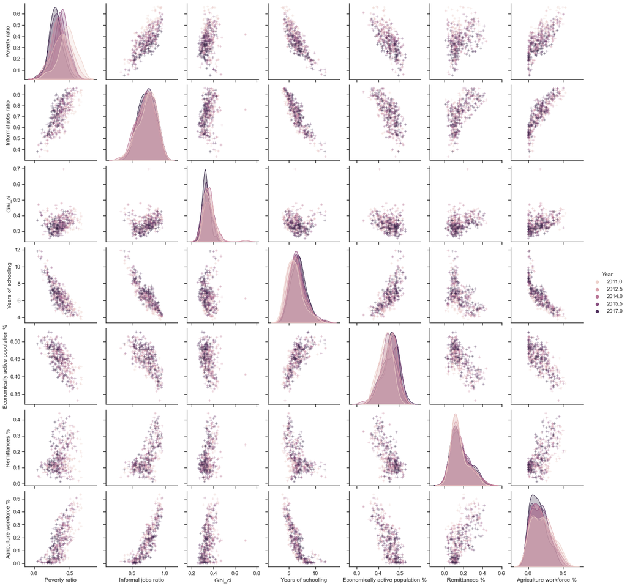

```python
import seaborn as sns; sns.set(style="ticks", color_codes=True)

g = sns.pairplot(data,
                vars = ['Poverty ratio','Informal jobs ratio','Gini_ci','Years of schooling',
                        'Economically active population %','Remittances %','Agriculture workforce %'],
                markers="+",
                hue = 'Year')
```

#### 2. How some indicators have changed during time

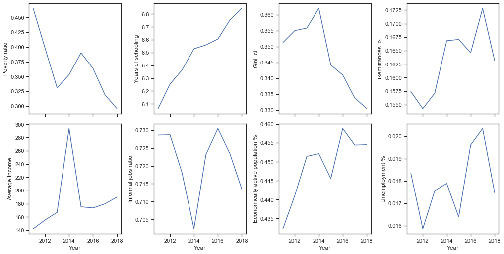

```python
import seaborn as sns
import matplotlib.pyplot as plt
from scipy import stats

#variables to plot
variables = ['Poverty ratio','Years of schooling', 'Gini_ci','Remittances %',
            'Average Income','Informal jobs ratio','Economically active population %',
            'Unemployment %', 'Year']


# Set up the matplotlib figure
f, axes = plt.subplots(2, 4, figsize=(14, 7), sharex=True, constrained_layout=True)


#plot each variable during time
variables.remove('Year')
cols = [0,1,2,3,0,1,2,3]
rows = [0,0,0,0,1,1,1,1]

for var,x, y in zip(variables,cols,rows):

    #droping outliers (Z score below 3)
    df1 = data[[var,'Year']][(np.abs(stats.zscore(data[[var,'Year']])) < 3).all(axis=1)]

    sns.lineplot(x='Year', y = var, ax = axes[y,x], data = df1, ci=None)
```

#### 3. Observing correlation between poverty and economic classification of work in the municipalities in 2018

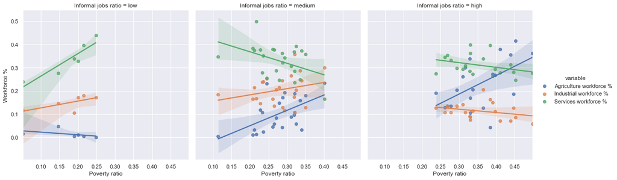

```python
#data ordered
df = pd.melt(data, id_vars=['Year','Poverty ratio','Informal jobs ratio'],
        value_vars=['Agriculture workforce %','Industrial workforce %', 'Services workforce %'])

df = df[df['Year']==2018]

df['Informal jobs ratio'] = pd.cut(df['Informal jobs ratio'],bins=3,labels=['low','medium','high'])

sns.set()

# Plot sepal with as a function of sepal_length across days
g = sns.lmplot(x='Poverty ratio', y="value", col='Informal jobs ratio',
               truncate=True, height=5, data=df, hue='variable')

# Use more informative axis labels than are provided by default
g.set_axis_labels("Poverty ratio", "Workforce %")
```

#### Reading csv file that contains more information of the municipalities as name and department

This information is not found in household surveys.

```python
os.chdir(r'/Users/eleno/Documents/Inter-American Development Bank Group/Personal - Investigación/Data')
inf_mun = pd.read_csv("info_mun.csv", encoding = 'latin-1')

#merging the new data
data2 = pd.merge(data, inf_mun[['NOM_MUN','COD_MUN4','NOM_DPTO','REG_GEO_DE']],
                 left_on='COD_MUN',right_on='COD_MUN4',how='left')

data2.rename(columns={'REG_GEO_DE':"Region", 'NOM_DPTO': "Departamento", 'NOM_MUN': "Municipio"}, inplace=True)
```

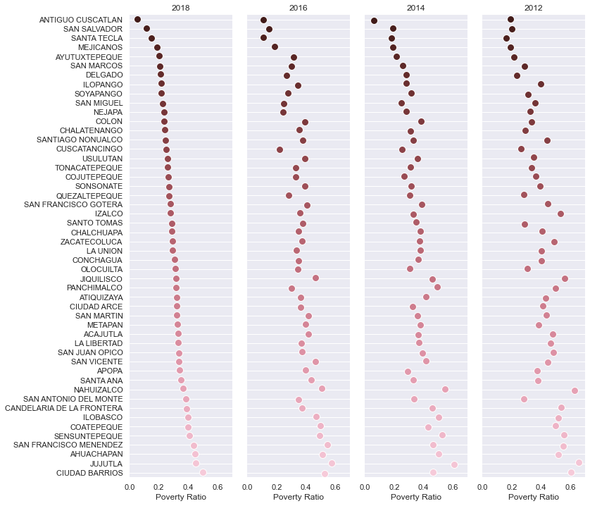

```python
#preparing data for the new graph
df = pd.pivot_table(data2, values = 'Poverty ratio', index = 'Municipio', columns = 'Year', aggfunc=np.sum).reset_index()

# Make the PairGrid
g = sns.PairGrid(df.sort_values(2018, ascending=True),
                 x_vars=[2018,2016,2014,2012], y_vars=["Municipio"],
                 height=10, aspect=.25)

# Draw a dot plot using the stripplot function
g.map(sns.stripplot, size=10, orient="h",
      palette="ch:s=1,r=-.1,h=1_r", linewidth=1, edgecolor="w")

# Use the same x axis limits on all columns and add better labels
g.set(xlim=(0, 0.70), xlabel="Poverty Ratio", ylabel="")

# Use semantically meaningful titles for the columns
titles = [2018,2016,2014,2012]

for ax, title in zip(g.axes.flat, titles):

    # Set a different title for each axes
    ax.set(title=title)

    # Make the grid horizontal instead of vertical
    ax.xaxis.grid(False)
    ax.yaxis.grid(True)

sns.despine(left=True, bottom=True)
```

```python
df = data2
fig = px.scatter(df, x='Years of schooling', y='Poverty ratio', color='Region', size='Population',
                facet_col='Year', facet_col_wrap=4)

fig.show()
```

[interactive chart not shown]

```python
#preparing data for the new graph
df = pd.pivot_table(data2, values = 'Poverty ratio', index = 'Municipio', columns = 'Year', aggfunc=np.sum).reset_index()
df.sort_values(2018, ascending=False,inplace=True)

fig = go.Figure()

fig.add_trace(go.Scatter(
    x=df[2011],
    y=df['Municipio'],
    name='Poverty: 2011',
    marker=dict(
        color='rgba(156, 165, 196, 0.95)',
        line_color='rgba(156, 165, 196, 1.0)',
    )
))
fig.add_trace(go.Scatter(
    x=df[2018], y=df['Municipio'],
    name='Poverty: 2018',
    marker=dict(
        color='rgba(204, 204, 204, 0.95)',
        line_color='rgba(217, 217, 217, 1.0)'
    )
))

fig.update_traces(mode='markers', marker=dict(line_width=1, symbol='circle', size=10))

fig.update_layout(
    title="Improvement in poverty levels",
    margin=dict(l=140, r=40, b=50, t=80),
    legend=dict(
        font_size=15,
        yanchor='middle',
        x=0.8, y=1
    ),
    width=800,
    height=1200,
    plot_bgcolor='white',
    hovermode='closest'
)
fig.update_yaxes(gridwidth=2, gridcolor='LightPink')

fig.show()
```

[interactive chart not shown]